# Efecto de la edad y cohorte sobre la participación en actividades relacionadas con la salud. Encuesta SHARE

La variable participacion toma los valores 0 y 1. Algunos descriptivos

## Efecto edad sobre participación

Veamos las tablas de edad (en grupos de edad) y participación

```
##              age_cat
## participacion (50,55] (55,60] (60,65] (65,70] (70,75] (75,80] (80,85]
##     no_partic    6992    8038    7734    6849    6029    4929    3413
##     partic       5989    6552    6637    5520    4243    2779    1494
##              age_cat
## participacion (85,90] (90,105]
##     no_partic    1522      495
##     partic        502      109
```

```
##              age_cat
## participacion (50,55] (55,60] (60,65] (65,70] (70,75] (75,80] (80,85]
##     no_partic  0.5386  0.5509  0.5382  0.5537  0.5869  0.6395  0.6955
##     partic     0.4614  0.4491  0.4618  0.4463  0.4131  0.3605  0.3045
##              age_cat
## participacion (85,90] (90,105]
##     no_partic  0.7520   0.8195
##     partic     0.2480   0.1805
```

Gráficamente

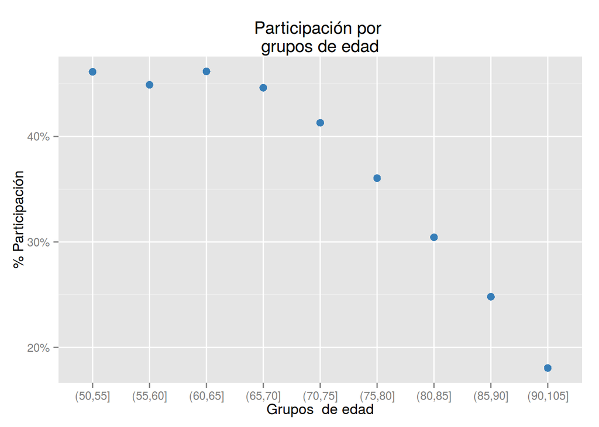

La participacion disminuye conforme aumenta la edad y esta disminución tiene un ritmo mayor a partir de los 70 años. Esto es compatible con un efecto cuadrático de la edad.

Para comprobarlo podemos calcular la proporción de participación en cada nivel de edad, y lo hacemos para cada ola. Esto se puede hacer calculándolo directamente.

```r
# lo hacemos con la edad categorizada para que no salga una tabla muy grande
with(share.clean.paises.3.olas,tapply(participacion, list(age_cat,id_ola),function(x)mean(x=="partic",na.rm=TRUE)))
```

```
##           Ola 1  Ola 2  Ola 4
## (50,55]  0.4234 0.4686 0.4892
## (55,60]  0.4070 0.4503 0.4810
## (60,65]  0.4058 0.4613 0.4983
## (65,70]  0.3746 0.4223 0.5119
## (70,75]  0.3366 0.4019 0.4687
## (75,80]  0.3089 0.3300 0.4142
## (80,85]  0.2535 0.2931 0.3404
## (85,90]  0.2198 0.2615 0.2536
## (90,105] 0.1833 0.1301 0.2050
```

**Lo que viene a continuación es sólo aclaratorio, y lo único que dice es que los modelos de regresión (lineales y logísticos) con predictores categóricos se pueden usar para calcular medias. A veces es mejor hacerlo así, ya que aparte de las medias nos dan también significación estadística y contrastes de diferencias de medias**

Una forma equivalente de calcular la proporción de participación en cada categoría de edad y ola es considerar un modelo de regresión logística donde añadimos la interacción entre age_cat e id_ola

```r
mod1 <- glm(participacion ~ age_cat * id_ola,family=binomial,data=share.clean.paises.3.olas)
# y ahora
share.clean.paises.3.olas$pred <- predict(mod1,newdata=share.clean.paises.3.olas,type="response")

with(share.clean.paises.3.olas,tapply(pred,list(age_cat,id_ola),mean))
```

```
##           Ola 1  Ola 2  Ola 4
## (50,55]  0.4234 0.4686 0.4892
## (55,60]  0.4070 0.4503 0.4810
## (60,65]  0.4058 0.4613 0.4983
## (65,70]  0.3746 0.4223 0.5119
## (70,75]  0.3366 0.4019 0.4687
## (75,80]  0.3089 0.3300 0.4142
## (80,85]  0.2535 0.2931 0.3404
## (85,90]  0.2198 0.2615 0.2536
## (90,105] 0.1833 0.1301 0.2050
```

Es decir, un modelo de regresión logística dónde consideramos las interacciones nos da una manera equivalente de calcular las medias de las proporciones, pero con la ventaja de que podemos ver la significativad.

**Hasta aquí la aclaración**

### Gráficos de participación por edad y ola

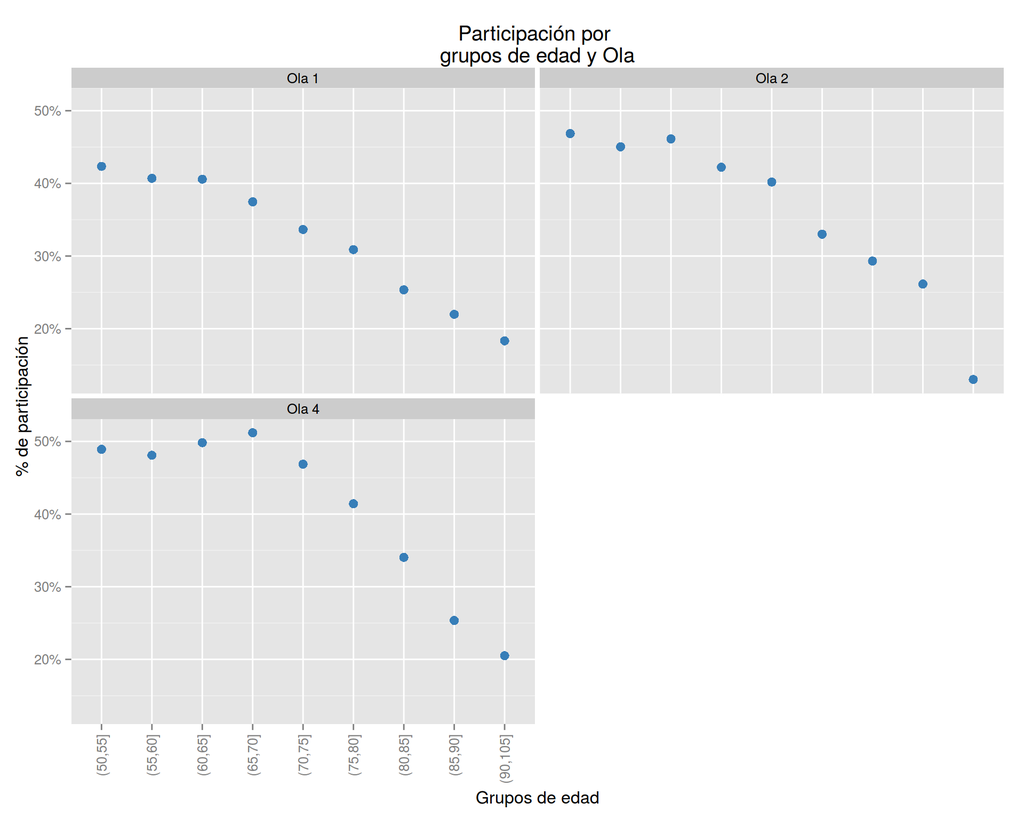

## Efecto cohortes

Podemos hacer un gráfico similar para las cohortes. Las cohortes consideradas son las siguientes.

```r
table(share.clean.paises.3.olas$dn003_cat)
```

```
##
## (1900,1920] (1920,1930] (1930,1935] (1935,1940] (1940,1945] (1945,1950]
##        1736       10464        9103       11800       13080       15437
## (1950,1955] (1955,1960] (1960,1965]
##       13026        6052         122
```

La tabla cruzada con edad es.

```r
with(share.clean.paises.3.olas,table(age_cat,dn003_cat))
```

```
##           dn003_cat
## age_cat    (1900,1920] (1920,1930] (1930,1935] (1935,1940] (1940,1945]
##   (50,55]            0           0           0           0           0
##   (55,60]            0           0           0           0        1005
##   (60,65]            0           0           0        1020        6136
##   (65,70]            0           0         835        5603        5552
##   (70,75]            0         689        4387        4890         387
##   (75,80]            0        3882        3644         287           0
##   (80,85]          259        4549         237           0           0
##   (85,90]          840        1289           0           0           0
##   (90,105]         637          55           0           0           0
##           dn003_cat
## age_cat    (1945,1950] (1950,1955] (1955,1960] (1960,1965]
##   (50,55]         1149        6246        5565         122
##   (55,60]         6985        6255         487           0
##   (60,65]         6818         525           0           0
##   (65,70]          485           0           0           0
##   (70,75]            0           0           0           0
##   (75,80]            0           0           0           0
##   (80,85]            0           0           0           0
##   (85,90]            0           0           0           0
##   (90,105]           0           0           0           0
```

### Gráficos de participación por cohortes y ola

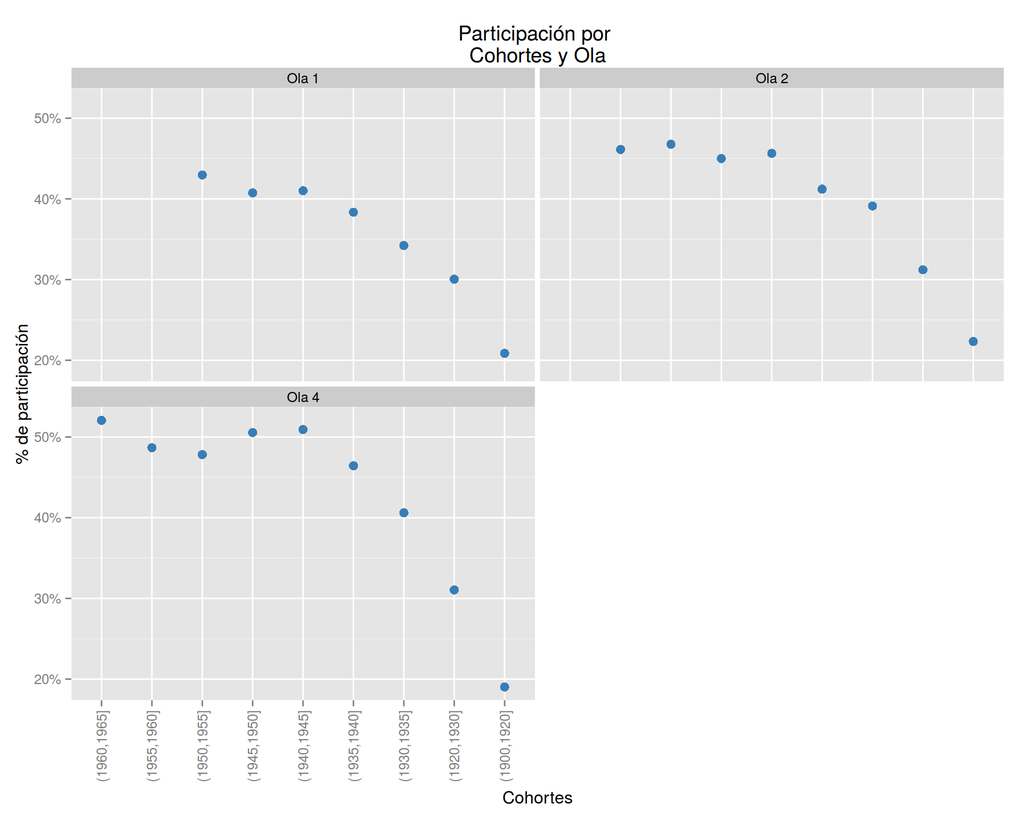

## Efecto de la edad y cohorte en cada ola

### Gráficos de participación por edad, cohorte y ola

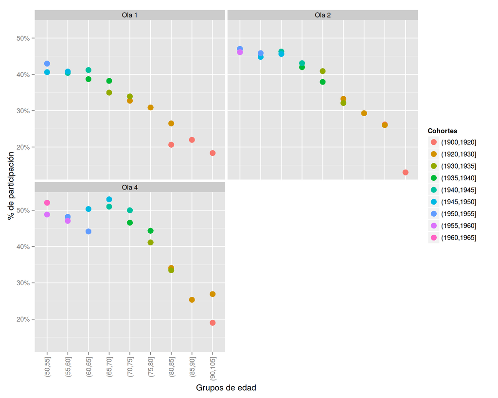

Viendo el gráfico de líneas al unir los puntos

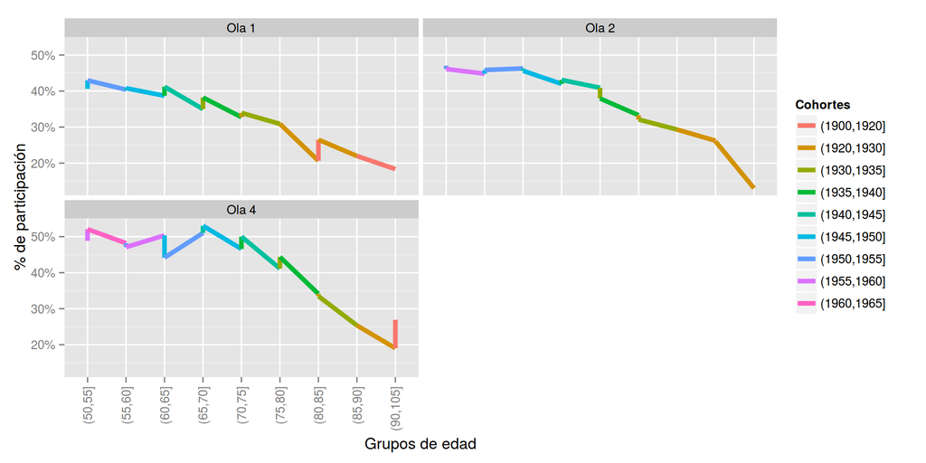